# Who publishes in “predatory” journals? - Xia - 2015 - Journal of the Association for Information Science and Technology - Wiley Online Library

[Journal of the Association for Information Science and Technology](https://asistdl.onlinelibrary.wiley.com/journal/23301643)

[Volume 66, Issue 7](https://asistdl.onlinelibrary.wiley.com/toc/23301643/2015/66/7) p. 1406-1417

[figure not shown]

RESEARCH ARTICLE

Full Access

# Who publishes in “predatory” journals?

[Jingfeng Xia](https://asistdl.onlinelibrary.wiley.com/action/doSearch?ContribAuthorStored=Xia%2C+Jingfeng)

[Jennifer L. Harmon](https://asistdl.onlinelibrary.wiley.com/action/doSearch?ContribAuthorStored=Harmon%2C+Jennifer+L)

[Kevin G. Connolly](https://asistdl.onlinelibrary.wiley.com/action/doSearch?ContribAuthorStored=Connolly%2C+Kevin+G)

[Ryan M. Donnelly](https://asistdl.onlinelibrary.wiley.com/action/doSearch?ContribAuthorStored=Donnelly%2C+Ryan+M)

[Mary R. Anderson](https://asistdl.onlinelibrary.wiley.com/action/doSearch?ContribAuthorStored=Anderson%2C+Mary+R)

[Heather A. Howard](https://asistdl.onlinelibrary.wiley.com/action/doSearch?ContribAuthorStored=Howard%2C+Heather+A)

First published: 06 November 2014

https://doi.org/10.1002/asi.23265

Citations: 119

## Abstract

Many open access journals have a reputation for being of low quality and being dishonest with regard to peer review and publishing costs. Such journals are labeled “predatory” journals. This study examines author profiles for some of these “predatory” journals as well as for groups of more well‐recognized open access journals. We collect and analyze the publication record, citation count, and geographic location of authors from the various groups of journals. Statistical analyses verify that each group of journals has a distinct author population. Those who publish in “predatory” journals are, for the most part, young and inexperienced researchers from developing countries. We believe that economic and sociocultural conditions in these developing countries have contributed to the differences found in authorship between “predatory” and “nonpredatory” journals.

## Introduction

A report published by *Science* in early October, 2013, triggered intense discussion among scholars and publishers on the issue of open access (OA) publishing and quality control (Bohannon, 2013). Bohannon, the author of this report, conducted an experiment by submitting a fabricated article with a deliberately flawed research design to a group of more than 300 selected OA journals. He wanted to check wehether the article would pass what some individuals believe to be a lax peer‐review process for many OA journals. The results supported the author's presumption, because more than half of the journals accepted the article and failed to notice or address the intentional flaws.

In recent years, we have seen the creation and growth of many OA journals. Various forms of publishing practices have been adopted. Some newly created OA journals lack transparency and do not identify an editorial board. Many require considerable article processing charges for authors. Such journals are considered to be primarily interested in making quick money and paying little or no attention to peer review (Beall, 2012a). Jeffrey Beall, at the University of Colorado Denver library, has called these “predatory” journals and has maintained a list of hundreds of such journals based on his set of criteria. His goal is to raise awareness of dishonest publishing practices.

Although there has been much discussion about the definition of “predatory” journals (Anderson, 2012; Poynder, 2013), it is clear that the quality of OA journals varies considerably. Many journals, including the ones on Beall's list, demonstrate low standards for article acceptance. Ideally, one would determine the merit of these journals by assessing the quality of their articles, but such an evaluation would be difficult to implement and could easily become too subjective. Instead, we choose to examine author profiles of these “predatory” journals, concentrating on their publication and citation histories and geographic location. We selected seven journals from Beall's “predatory” journal list in the area of biomedical science, collecting data for a total of 324 articles and 941 authors. We also consulted the Web of Science for each author's total number of publications and citations as an indicator of academic reputation. The data set was then compared with that of authors in various groups of other OA journals. One group includes journals that rejected Bohannon's fake article and are not listed by Beall; another group includes journals with recognized prestige as indicated by their high journal impact factors. The purpose of this study is to determine whether the different groups of OA publications have attracted different types of authors; in other words, can author profiles indicate the scholarly standards of OA journals.

## Background

There are very few scholars who have not received e‐mail spam from new OA journals and conferences attempting to recruit articles or solicit participation, often containing invitations to participate in the journal's review or become members of the journal's editorial team. Some OA publishers have been so aggressive in their marketing efforts that scholars may easily become overwhelmed by the frequency of such e‐mails and, as a consequence, may grow skeptical about OA publishing. Beall began investigating OA publishers and created a blacklist of what he calls “predatory” journals and publishers that are considered to be dishonest and of low quality. Journals that are included on Beall's list may be known to accept submissions quickly with little peer review, publish hoax or nonsensical papers, require a processing fee after a publishing agreement is signed, appoint fake scholars to the editorial board, and mimic the name of a more well‐recognized journal.

Bohannon, a journalist for *Science*, took a different route to verifying the quality of OA publishing. He used a false name and fictitious institution to submit 304 copies of a paper about a “wonder drug” to selected OA journals, but the paper itself contained an experimental design “so hopelessly flawed that the results are meaningless” (Bohannon, 2013, p. 60). At the time of publication of his study in *Science*, Bohannon's flawed paper had been accepted 157 times and rejected 98 times. His other submissions were either still under review or had yet to receive a response. Among the 255 acceptances and rejections, 60% did not show any evidence of peer review; among those that did, not all of the peer review focused on the scientific soundness of the bogus study.

Bohannon's research received immediate attention and criticism in the media. Many blog entries started discussing the report as soon as it became available, attracting hundreds of responses (e.g., Eisen, 2013; Taylor, Wedel, & Naish, 2013). Although many people supported his “sting operations” on potentially dishonest OA publishers, some criticized his methods or arguments or the ethicality of his conduct.

Bohannon's experiment, like his fabricated paper, did not include a control group. He targeted OA journals without bringing subscription‐based journals into the study. Lax control of publication quality is not unique to OA; rather, it is a problem that has been in existence in scholarly communication for a long time (Bornmann, 2011; Lee, Sugimoto, Zhang, & Cronin, 2013). In fact, as early as 1996, Alan Sokal conducted a similar test, known as the Sokal Affair, by submitting a questionable article to *Social Text*, a leading scholarly journal in the United States in the area of postmodern cultural studies (Sokal, 1996a). On the date of the article's publication, Sokal indicated that the article was a hoax (Sokal, 1996b,c). There have also been a number of comparable experiments on non‐OA journals as well as OA journals (see en.wikipedia.org/wiki/Sokal_affair;scholarlyticken.org; Gilbert, 2009; Peters & Ceci, 1982).

Bohannon equated low‐quality OA publications with open access in general in his argument. However, his approach to data collection is debatable because only OA journals charging a processing fee were included in the experiment. Peter Suber points to the fact that as many as 70% of journals listed in the *Directory of Open Access Journals* (DOAJ) in 2013 charged no author‐side fees at all (Suber, 2006, 2013). Bohannon's discussion also contradicts itself in that it provides proof that some fee‐based OA journals, such as *PLoS One*, did conduct rigorous peer review and rejected his bogus paper.

He received further criticism on an ethical basis because authors are required to guarantee their submission represents a true scientific study. This argument appears to come from irritated publishers who did not appreciate being tricked by Bohannon and the journal *Science* that backed and published the study (Oransky, 2013).

Disagreements aside, nobody denies that there are indeed many weak and disreputable journals. Those dishonest journals have contributed to some individuals having doubts about the reputation of the OA field. Through tracing the Internet protocol (IP) addresses of journal editors and the location of their bank accounts, Bohannon (2013) found that many of the journals accepting his fake article were based in developing countries, particularly India. Four major geographical clusters of “predatory” publishers were found in India, Nigeria, the U.S., and the U.K. A common practice has emerged in which many such OA publications are run in India with branches in the latter two countries. Journals without rigorous quality control are especially harmful for developing countries “where governments and universities are filling up with people with bogus scientific credentials,” according to Ginsparg, founder of the physics e‐print repository arXiv (cited from Bohannon, 2013, p. 65). Sociocultural and economic factors have played an important role in the geographic formation of this “predatory” OA publishing.

Young researchers and doctoral students in these developing countries are considered to be the major victims of predatory journals, a problem catalyzed by an increasing pressure for them to “publish or perish” (Shaw, 2013). They are anxious to expand their publication list and become recognized by the academic community and are therefore easily attracted by the quick and easy publishing model that these OA journals offer. Presumably, many authors who publish in these dubious “new ‘pay big, publish fast’ e‐journals are younger scholars based in the Global South and particularly in the Muslim world” (Truth, 2012, p. 56).

Very few scientific studies have examined “predatory” journals, although there have been informal discussions about this topic on personal blogs (e.g., Taylor et al., 2013). Fewer, if any, scientific studies have been conducted to investigate the background of authors of OA journal articles. Our current project on OA authorship in predatory journals will shed light on the issues relating to journal quality control and scholar involvement in making contributions to weak and dishonest journals and will help the academic community to refine its culture in response to the changing environment of scholarly communication. We study the background variables of those authors who publish in journals that require publication fees so that the findings can be compared with what Bohannon discovered. However, we take a further step to improve our research design by introducing comparable groups, namely, authors from established OA journals that also charge author fees, including journals rejecting Bohannon's fake paper and journals with high status from the PLoS series.

Based on the existing observations and arguments, we present the following hypotheses: 1. Hypothesis One: There is no difference in author profiles, regarding their publication and citation history, between the various groups of OA journals if these journals all employ an author‐fee model. 2. Hypothesis Two: There is no difference in author profiles, regarding their geographic location, between the various groups of OA journals if these journals all employ an author‐fee model.

## Research Design

### Data Collection

We selected a group of 68 journals from Beall's predatory journal list to represent low‐quality publications in various areas of biomedical science, primarily pharmaceutical science, which is comparable to the subject of Bohannon's false study. We chose to investigate biomedical science because (a) open access has been an established practice among biomedical scientists, (b) many biomedical projects are sponsored by grants that could fund OA publishing, making an author‐pay model possible and popular, and (c) there are some recognized biomedical journals with the same or similar publishing models that can be used for the purpose of comparison. Among these 68 journals, 7 journals were selected for data collection of author profiles because of their focus on pharmaceutical science according to the titles (Table 1). We call this group 1.

Table 1. Journals selected for the study: Group 1 “predatory” journals, group 2 journals rejecting Bohannon's false paper

|  | Journal | Article count | Author count | Frequency | First issue | Location<sup>a</sup> | Per paper<sup>b</sup> |
| --- | --- | --- | --- | --- | --- | --- | --- |
| Group 1 | *American Journal of Pharmacy and Health Research (AJPHR)* | 48 | 102 | Monthly | Apr, 2013 | India | 16 (50)<sup>c</sup> |
|  | *Indian Journal of Pharmaceutical and Biological Research (InJPBR)* | 34 | 70 | Quarterly | Jan–Mar, 2013 | India | 12 (40)<sup>c</sup> |
|  | *International Journal of Life science and Pharma Research (IJLSPR)* | 26 | 65 | Quarterly | Oct–Dec, 2011 | India | Unknown |
|  | *International Journal of Medical Sciences and Health Care (IJMSHC)* | 19 | 69 | Monthly | Jan, 2013 | U.S. | 200 |
|  | *International Journal of Pharmaceutical and Biomedical Research (IJPBR)* | 42 | 139 | Quarterly | Jan–Mar, 2010 | U.K. | Unknown |
|  | *International Journal of Pharmaceutical Sciences and Drug Research (IJPSDR)* | 24 | 96 | Quarterly | Apr–Jun, 2009 | India | 16 |
|  | *International Journal of Pharmacy (IJP)* | 131 | 400 | Quarterly | 2011 | Turkey | 33 (225)<sup>c</sup> |
| Group 2 | *British Journal of Pharmaceutical Research (BJPR)* | 84 | 327 | Quarterly | Jan, 2011 | India | 500 |
|  | *Cancer Growth and Metastasis (CGM)* | 5 | 11 | Rolling | 2008 | U.S. | 1,699 |
|  | *Clinical and Molecular Hepatology (CMH)* | 24 | 145 | Quarterly | 1995 | Korea | Unknown |
|  | *Drugs and Therapy Studies (DTS)* | 5 | 22 | Rolling | 2011 | Sweden | 272 |
|  | *Frontiers in Pharmacology of Anti‐Cancer Drugs (PACD)* | 47 | 229 | Monthly | Sept, 2010 | Switzerland | 2,176<sup>d</sup> |
| Total |  | 489 | 1,675 |  |  |  |  |

- *Note.* <sup>a</sup>Location refers to the location of journal editor.
- <sup>b</sup>Per paper values are presented in U.S. dollars for the sake of comparison. Currency conversions were calculated in early January, 2014.
- <sup>c</sup>The first amount is for a local submission or a submission from selected developing countries; the amount in parentheses is for a submission from the West.
- <sup>d</sup>This amount is for a regular submission of most types of research papers.

To make the comparisons, two other groups of OA journals were also selected. One group includes journals that rejected Bohannon's fake paper (Table 1). Other criteria used to select these journals are (a) journals have a substantial review process according to Bohannon, (b) journals require author payment, (c) journals in the same biomedical areas, and (d) journals have registered with the DOAJ but are not on Beall's list. The DOAJ aims to “cover all open access scientific and scholarly journals that use a quality control system to guarantee the content” (doaj.org/about). Although these journals have not been rated by popular bibliometric tools such as *Journal Citation Reports* by Thomson Reuters or *SCImago Journal & Country Rank*, we consider them to be more rigorous in peer review and to represent better quality than the predatory journals in group 1. In total, five journals were selected for the study. Note that the location data in the tables are for journal editors, which is consistent with Bohannon's study. We call this group 2.

The other group contains high‐status journals from the PLoS series. PLoS (the Public Library of Science) is a nonprofit publisher, with its journals establishing OA “as an effective and sustainable way to share the latest and best research with everyone” (http://www.plos.org/about/plos). Since October, 2003, PLoS has launched seven journals, all of which have been widely accepted as high‐quality publications. Their impact factor and h‐index values, as shown in Table 2, indicate the popularity of the journals in the scientific world. Among these seven PLoS journals, two were removed from our study (*PLoS Computational Biology* and *PLoS One*) because of their wide coverage of research subjects. These journals all charge publication fees to authors, and the cost per article is very high (Table 2). We call this group 3.

Table 2. Group 3: Selected PLoS journals and their rankings by impact factor and h‐index (Sources: *Journal Citation Reports*, Thomson Reuters; *SCI**mago Journal &* *C**ountry* *R**ank*; and PLoS)

| Journal | Impact fact | h‐index | Per paper |
| --- | --- | --- | --- |
| *PLoS Biology* | 12.69 | 133 | $2,900 |
| *PLoS Medicine* | 15.253 | 105 | $2,900 |
| *PLoS Computational Biology* | 4.867 | 72 | $2,250 |
| *PLoS Genetics* | 8.517 | 93 | $2,250 |
| *PLoS Pathogens* | 8.136 | 78 | $2,250 |
| *PLoS neglected tropical diseases* | 4.963 | 40 | $2,250 |

Aside from the PLoS journals, data for all research articles published in 2013 were collected in a spreadsheet, resulting in a total of 324 articles for group 1 and 165 articles for group 2. The data for every author of these articles were manually entered into the spreadsheet, including the author's full name, institutional affiliation, geographical location, academic status, and corresponding authorship. In total, 1,821 authors were collected (group 1 = 1,047 and group 2 = 774). After removal of duplicates, the final number of authors was 1,675 (group 1 = 941 and group 2 = 734).

Next, we searched for each author's publications and citations in the Web of Science, with the results being further refined by the research area of biomedical science only. In other words, even if an author had published in multiple disciplines, only his publications and citations in biomedical science were counted. Given the specialization of biomedical studies, we believe such a refinement will not result in a significant variation for a researcher's overall academic reputation.

The same data‐collection strategy was applied for authors who published in 2013 in group 3 journals. For this data set, we did not select all articles in 2013 because of the large quantity. Instead, we chose the first issue of each journal, following the data‐collection strategy adopted by Finlay, Ni, Tsou, and Sugimoto (2013) and stopped data collection when the number of authors reached 300, a number that we believe sufficient for the purpose of comparison. These samples are roughly evenly distributed across all five journals.

### Data Analyses

The χ<sup>2</sup> test of independence was selected for the analyses in order to evaluate whether paired observations on variables, expressed in a contingency table, are independent of each other between group 1 and group 2 journals and between group 2 and group 3 journals. Known also as the test of homogeneity, the test of independence seeks an χ<sup>2</sup> probability of less than or equal to 0.05 to reject a null hypothesis that row variable is independent of column variable. To make reliable statistical tests, we used randomly selected samples and paid special attention to the size of the samples so that no more than 25% of the cells in the contingency table for our χ<sup>2</sup> calculations have a value lower than 5. This sample size justification made it impossible for us to run statistical analysis against data for journals within a group. For example, we were unable to compare the difference of author profiles among the seven predatory journals. Our χ<sup>2</sup> analyses below are all intergroup comparisons, which is exactly what we need for this study.

### Limitations

We recognize the complexity of authorship (Cronin, 2005), particularly in the area of biomedical research. Biomedical papers often contain many coauthors who make varying degrees of contribution. In some cases, a doctoral student, who will need first‐authored articles to compete for employment, is listed as the first author of an article even though his academic advisor initiated and contributed to the research. As a result, analyses at the level of all individual authors might not paint an accurate picture of authorship. Therefore, we conducted additional analyses by applying χ<sup>2</sup> calculations against the corresponding authors as a subset of our existing data.

The sample size of this research is relatively small, particularly for the comparison groups. This small size limits our analyses on the data within any group of journals. Although the limitation will not affect intergroup comparisons in this case, future studies may expect to examine more features of OA journal publishing by expanding sample size.

## Analyses

### All Authors

For an χ<sup>2</sup> analysis at the level of individual authors, Tables 3 and 4 provide counts of articles by author from the three groups of journals. A statistical analysis at the individual journal level is impossible because of the small numbers in some strata. Table 4 does not show strata at the journal level, also because of the size of the data. The total numbers of each group, rather than journal numbers, are used for the following calculations.

Table 3. Group 1 and 2 journals by number of authors in various publication strata (journal title acronyms are given in Table 1)

|  | Journal | 0 | 1–5 | 6–10 | 11–15 | 16–20 | 21–25 | 26–30 | 30+ | Total |
| --- | --- | --- | --- | --- | --- | --- | --- | --- | --- | --- |
| Group 1 | *AJPHR* | 81 | 16 | 2 | 2 | 1 | 0 | 0 | 0 | 102 |
|  | *InJPBR* | 43 | 18 | 3 | 2 | 1 | 0 | 1 | 2 | 70 |
|  | *IJLSPR* | 42 | 17 | 3 | 0 | 1 | 1 | 0 | 1 | 65 |
|  | *IJMSHC* | 44 | 18 | 4 | 0 | 0 | 2 | 0 | 1 | 69 |
|  | *IJPBR* | 98 | 41 | 0 | 0 | 0 | 0 | 0 | 0 | 139 |
|  | *IJPSDR* | 56 | 23 | 5 | 2 | 5 | 1 | 0 | 4 | 96 |
|  | *IJP* | 249 | 90 | 46 | 2 | 0 | 0 | 3 | 10 | 400 |
|  | Total | 613 | 223 | 63 | 8 | 8 | 4 | 4 | 18 | 941 |
| Group 2 | *BJPR* | 80 | 127 | 64 | 24 | 0 | 16 | 0 | 16 | 327 |
|  | *CGM* | 2 | 4 | 2 | 0 | 2 | 1 | 0 | 0 | 11 |
|  | *CMH* | 19 | 36 | 8 | 6 | 10 | 16 | 10 | 40 | 145 |
|  | *DTS* | 4 | 4 | 2 | 1 | 2 | 1 | 2 | 6 | 22 |
|  | *PACD* | 36 | 85 | 36 | 18 | 9 | 5 | 0 | 40 | 229 |
|  | Total | 141 | 256 | 112 | 49 | 23 | 39 | 12 | 102 | 734 |
| Overall total |  | 754 | 479 | 175 | 57 | 31 | 43 | 16 | 120 | 1,675 |

Table 4. Group 3 journals by number of authors in various publication strata

| Journal | 0 | 1–5 | 6–10 | 11–15 | 16–20 | 21–25 | 26–30 | 30+ | Total |
| --- | --- | --- | --- | --- | --- | --- | --- | --- | --- |
| PLoS Journals | 16 | 108 | 52 | 36 | 13 | 20 | 3 | 52 | 300 |

The χ<sup>2</sup> test of independence indicates significant differences in the publication records of authors between group 1 and group 2 journals. The differences reject our first hypothesis. In other words, we are 95% confident that authors of these two groups have different academic reputations. The same interpretation is given to the χ<sup>2</sup> test between groups 2 and 3. The testing result also indicates that PLoS authors are significantly different from group 2 authors based on their publication history. Similarly, the third χ<sup>2</sup> test serves as supplemental evidence to support the former two sets of calculations. Differences are found among these three groups of authors.

The χ<sup>2</sup> model is able to test whether there is a statistical significance in data by comparing whether the variation in a set of data is due to chance or to one of the variables being tested. Although it is very powerful and useful for scientific research, the χ<sup>2</sup> test does not provide necessary information about the reasons for the significance or lack thereof. To understand the author profiles better, we create a simple histogram visualization to check whether certain patterns in the authorship can be detected.

Figure 1 is self‐explanatory and illustrates an obvious contrast in author publication records between the two groups. The majority of authors who publish in predatory journals have no other publications, whereas the second largest group consists of authors with fewer than five journal publications elsewhere; very few authors have published more than 10 articles. In contrast, the histogram reveals that group 2 authors, those who publish in OA journals that have a robust review process and subsequently rejected Bohannon's false submission, generally have a stronger publication record. With the exception of a few new authors, most group 2 authors have published journal articles previously; in fact, some authors have published more than 30 articles.

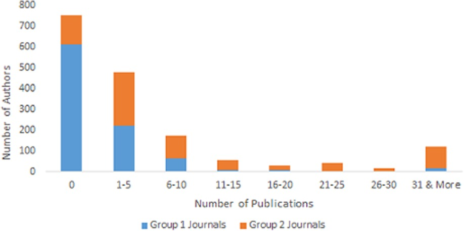

**Figure 1**

Comparison of journal groups by number of authors in various publication strata. [Color figure can be viewed in the online issue, which is available at [wileyonlinelibrary.com](http://wileyonlinelibrary.com/).]

We attempted to examine the academic status of group 1 authors further, but the data are incomplete because many journals, particularly predatory journals, do not provide their authors' academic rank. A Google search is not helpful because the majority of these authors do not have a personal webpage, and their institutional websites are, more often than not, too poorly designed to provide the information. From the data we collected, there seems to be an indication that young researchers, including doctoral students and assistant professors, have fewer publications than authors with the title professor. However, the data are insufficient to support the assertion statistically.

Citation counts for the strata are listed in Tables 5 and 6. Table 6 has the citation counts by author for the entire group 3. A similar χ<sup>2</sup> test was taken for the citation counts. The results confirm the aforementioned test for publication history and reject our first hypothesis, again at the significant level of 0.05. From this testing result, we are confident there are significant differences in citations among authors of the different groups.

Table 5. Group 1 and 2 journals by number of authors in various citation strata (journal title acronyms are given in Table 1)

|  | Journal | 0 | 1–5 | 6–10 | 11–15 | 16–20 | 21–25 | 26–30 | 30+ | Total |
| --- | --- | --- | --- | --- | --- | --- | --- | --- | --- | --- |
| Group 1 | *AJPHR* | 84 | 14 | 0 | 2 | 0 | 0 | 0 | 2 | 102 |
|  | *InJPBR* | 55 | 8 | 2 | 2 | 1 | 0 | 0 | 2 | 70 |
|  | *IJLSPR* | 47 | 9 | 1 | 1 | 0 | 0 | 3 | 4 | 65 |
|  | *IJMSHC* | 50 | 7 | 1 | 1 | 2 | 4 | 3 | 1 | 69 |
|  | *IJPBR* | 99 | 11 | 6 | 2 | 1 | 0 | 3 | 17 | 139 |
|  | *IJPSDR* | 64 | 11 | 2 | 2 | 1 | 1 | 0 | 15 | 96 |
|  | *IJP* | 270 | 52 | 14 | 16 | 7 | 5 | 11 | 25 | 400 |
|  | Total | 669 | 112 | 26 | 26 | 12 | 10 | 20 | 66 | 941 |
| Group 2 | *BJPR* | 114 | 74 | 25 | 9 | 16 | 16 | 16 | 57 | 327 |
|  | *CGM* | 3 | 2 | 0 | 0 | 1 | 0 | 0 | 5 | 11 |
|  | *CMH* | 39 | 12 | 8 | 2 | 3 | 3 | 1 | 77 | 145 |
|  | *DTS* | 4 | 1 | 1 | 1 | 1 | 0 | 0 | 14 | 22 |
|  | *PACD* | 44 | 18 | 4 | 18 | 4 | 18 | 13 | 110 | 229 |
|  | Total | 204 | 107 | 38 | 30 | 25 | 37 | 30 | 263 | 734 |
| Grand Total |  | 873 | 219 | 64 | 56 | 37 | 47 | 50 | 329 | 1,675 |

Table 6. Group 3 journals by number of authors in various citation strata

| Journal | 0 | 1–5 | 6–10 | 11–15 | 16–20 | 21–25 | 26–30 | 30+ | Total |
| --- | --- | --- | --- | --- | --- | --- | --- | --- | --- |
| PLoS Journals | 16 | 44 | 21 | 10 | 10 | 8 | 3 | 188 | 300 |

We then followed this procedure to create a histogram for group 1 and group 2 (Figure 2). The data show much stronger evidence that authors who publish in group 2 journals have accumulated more extensive citations than authors in the group 1 journals. The largest number of citations falls in the stratum “30+” for group 2 authors, whereas most group 1 authors still have not received any citations.

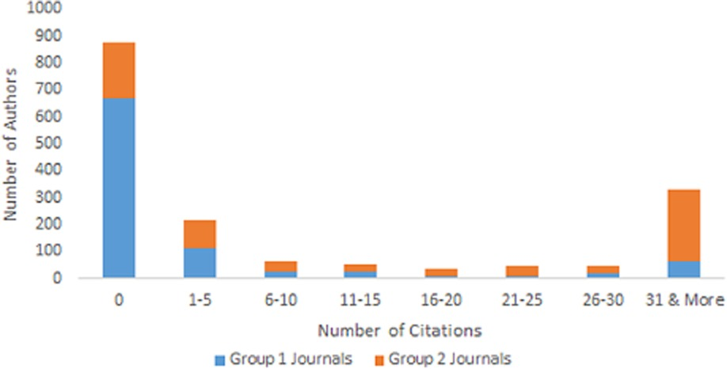

**Figure 2**

Comparison of journal groups by number of authors in various citation strata. [Color figure can be viewed in the online issue, which is available at [wileyonlinelibrary.com](http://wileyonlinelibrary.com/).]

### Corresponding Authors

Because of the complexity of coauthorship in biomedical sciences, corresponding authors may not be the first author (Riesenberg & Lundberg, 1990; Shapiro, Wenger, & Shapiro, 1994), yet we believe that they usually play an important role and typically make intellectual contributions to a study. Most importantly, they may be the most senior researcher of a group and decide where to submit a research article. Their publication history may offer important information in understanding why a particular OA journal is selected, or, in other words, what relationship may exist between the status of a journal and its authorship. Because many journals in our samples have a limited number of articles and corresponding authors, we will not present data for individual journals (Tables 7 and 8). There are some variations in the data; for example, certain articles have more than one corresponding author, and some articles are shared by the same corresponding authors. These variations, however, are few and will not affect our test at the group level. The following χ<sup>2</sup> testing results also reject our first hypothesis and show significant differences among authors of the different groups.

Table 7. Group 1 and 2 journals by number of corresponding authors in various publication strata

|  | 0 | 1–5 | 6–10 | 11–15 | 16–20 | 21–25 | 26–30 | 30+ | Total |
| --- | --- | --- | --- | --- | --- | --- | --- | --- | --- |
| Group 1 journals | 204 | 83 | 23 | 6 | 2 | 0 | 0 | 6 | 324 |
| Group 2 journals | 13 | 28 | 32 | 6 | 19 | 13 | 16 | 38 | 165 |
| **Total** | 217 | 111 | 55 | 12 | 21 | 13 | 16 | 44 | 489 |

Table 8. Group 1 and 2 journals by number of corresponding authors in various citation strata

|  | 0 | 1–5 | 6–10 | 11–15 | 16–20 | 21–25 | 26–30 | 30+ | Total |
| --- | --- | --- | --- | --- | --- | --- | --- | --- | --- |
| Group 1 Journals | 233 | 41 | 12 | 6 | 2 | 5 | 10 | 15 | 324 |
| Group 2 Journals | 15 | 15 | 11 | 4 | 7 | 4 | 8 | 101 | 165 |
| Total | 248 | 56 | 23 | 10 | 9 | 9 | 18 | 116 | 489 |

Figures 3 and 4 demonstrate different patterns of publication and citation distributions across the strata for authors in each group. We especially note the considerable citation counts in the stratum “30+” for authors in group 2 (Figure 4). Evidently, the corresponding authors in group 2 have received far more citations than those in group 1.

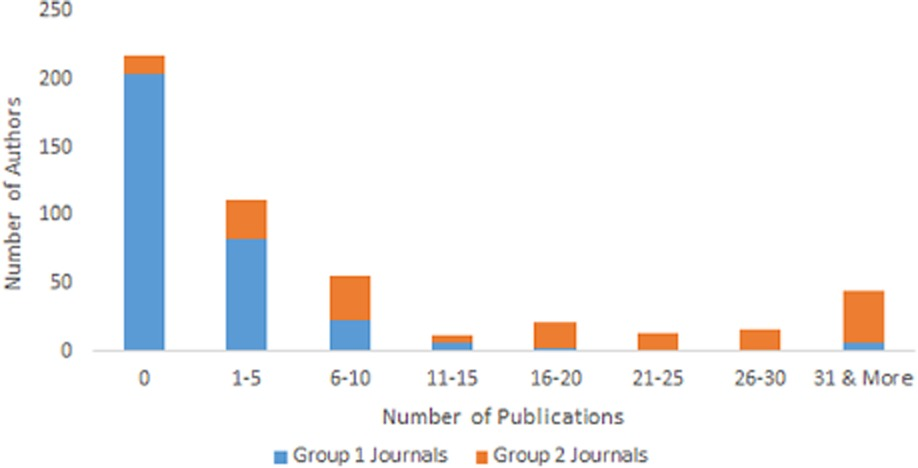

**Figure 3**

Comparison of journal groups by number of corresponding authors in various publication strata. [Color figure can be viewed in the online issue, which is available at [wileyonlinelibrary.com](http://wileyonlinelibrary.com/).]

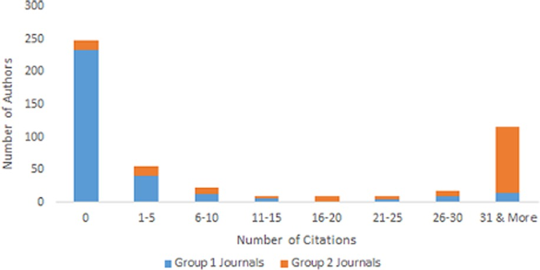

**Figure 4**

Comparison of journal groups by number of corresponding authors in various citation strata. [Color figure can be viewed in the online issue, which is available at [wileyonlinelibrary.com](http://wileyonlinelibrary.com/).]

### Author Geographic Locations

Table 9. Geographic location of authors

|  | Author country |
| --- | --- |
| Group 1 | Algeria, Bangladesh, Brazil, Cameroon, Egypt, Ethiopia, India, Indonesia, Iran, Italy, Kenya, Lebanon, Malaysia, Malta, Mexico, Morocco, Nepal, Nigeria, Pakistan, Saudi Arabia, Thailand, U.A.E., U.K. |
| Group 2 | Australia, Brazil, Canada, Egypt, Germany, India, Italy, Korea, Nigeria, Switzerland, U.S. |
| Group 3 | Australia, Canada, China, France, Germany, Italy, Nigeria, Switzerland, Tanzania, Uganda, U.K., U.S. |

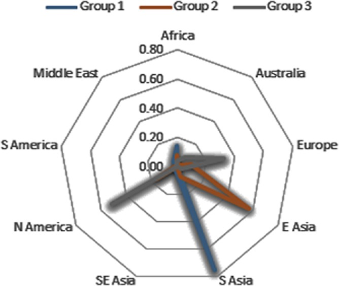

**Figure 5**

Comparison of journal groups by geographic location of authors. [Color figure can be viewed in the online issue, which is available at [wileyonlinelibrary.com](http://wileyonlinelibrary.com/).]

To conduct an χ<sup>2</sup> analysis, we reclassify the numbers so that zeroes can be removed. In the reclassification, the Middle East, which is not present in groups 2 and 3 at all, is merged into Africa; Southeast Asia, which is not found in groups 2 and 3, is combined with East Asia; and South America, which contains Brazil only and is presented merely in group 2, is combined with North America to become Americas (Tables 10 and 11).

Table 10. Comparison of journal groups by location of authors in percentage

|  | Group 1 | Group 2 | Group 3 |
| --- | --- | --- | --- |
| Africa | 0.14 | 0.08 | 0.04 |
| Australia | 0.00 | 0.01 | 0.09 |
| Europe | 0.01 | 0.10 | 0.33 |
| E Asia | 0.00 | 0.57 | 0.03 |
| S Asia | 0.75 | 0.07 | 0.00 |
| SE Asia | 0.03 | 0.00 | 0.00 |
| N America | 0.03 | 0.16 | 0.51 |
| S America | 0.00 | 0.01 | 0.00 |
| Middle East | 0.04 | 0.00 | 0.00 |
| Total | 1.00 | 1.00 | 1.00 |

Table 11. Comparison of journal groups by location of authors in number

|  | Group 1 | Group 2 | Group 3 |
| --- | --- | --- | --- |
| Africa | 189 | 61 | 13 |
| Australia | 0 | 7 | 25 |
| Europe | 14 | 76 | 98 |
| E Asia | 29 | 438 | 10 |
| S Asia | 784 | 57 | 1 |
| Americas | 31 | 135 | 153 |
| Total | 1,047 | 774 | 300 |

The χ<sup>2</sup> tests of independence indicate significant differences in author geographic origin among the groups. All three tests at the significance level of 0.05 reject our second hypothesis that there is no difference in author profiles with regard to geographic location, among the various groups of OA journals. The results are consistent with our casual observation in Figure 5.

There is another difference among the three groups regarding the geographic location of multiple authors. In group 1, when the primary or corresponding author of an article is not from a developed country, which is standard, other coauthors are typically also not from developed countries. For group 3 journals, research collaborations between developing and developed countries are common. Group 2 falls between these two groups.

## Discussion

Bohannon assumed that OA journals were dishonest and of low quality. He attempted to prove this and focused discussion in his *Science* paper on the negative aspects of OA publishing. The fact is that, although 60% of the OA journals accepted his false research, 40% of OA journals also rejected the article. He did not pay attention to different OA practices but instead singled out the validity of Beall's judgment for being “good at spotting publishers with poor quality control” (Bohannon, 2013, p. 64).

Both Bohannon's study and Beall's criteria for filtering predatory journals, as well as numerous blog posts on similar subjects, have discussed OA practices from a publisher's perspective. OA contributors have been largely ignored in this discussion. Knowing who publishes in predatory journals will be useful. Our data, for both corresponding authors and other coauthors, indicate that these researchers are young, inexperienced, and often located in developing countries. The fact that they have paid various amounts in article processing charges to publish their articles in new and low‐prestige OA journals signifies their eagerness to build publication records. We believe that sociocultural and economic conditions in the countries where most of these authors reside have played a critical role in shaping the authorship landscape.

Let us look at the two countries with the most authors who publish in predatory journals. In India, a long‐standing digital divide has created an imbalance of information access and dissemination within the scholarly community (Ghosh & Das, 2007). A rapid growth of the economy has helped construct necessary facilities for elite institutions and universities to support research and teaching in recent years, but other institutions have been struggling to amass new technologies and research sponsorship. There has been a shortage of platforms to fulfill the demands of scholarly publishing. The publishing market is traditionally not a huge economic entity in many developing countries, which has given OA initiatives sufficient space to expand in these areas. As the second most populous nation in the world, India has about 300 universities and nearly the same amount of government‐funded research laboratories, yet its research output in science and technology, according to the Web of Science, was only about 2.5% of the world's journal literature in 2006 (Arunachalam, 2006). In a geographic analysis of scholarly publishing, Haider (2006) found that India was ranked 12th in general journal publishing and 18th in publishing of online content among the top 25 publishing countries. By 2008, India was ranked fifth in OA journal publishing, with a total of 150 OA journals (Nazim & Devi, 2008). For researchers and scholarly publishers, “there are enormous rewards of sheer recognition and access to a broad and diverse audience; these factors overcome economic and financial inhibitions to publish on the web with open access” (Abraham & Minj, 2007).

The expansion of OA journal publishing in India has been very rapid since then. Today, India is ranked 10th in number of papers and 16th in number of citations according to *SCImago Journal & Country Rank* (http://www.scimagojr.com/countryrank.php), and the country is ranked fourth in OA journal publishing, with 593 OA journals appearing in DOAJ and 604 OA journals according to Ulrichsweb.

The condition of scholarly publishing in Nigeria can also help explain why so many inexperienced authors choose easy‐to‐publish OA journals. Research in Nigeria has been strongly recommended for advancement in academia and other research institutions (Adomi & Mordi, 2003; Mordi, 2002). Many Nigerian universities and research institutions require their staff to publish a specific proportion of their journal articles in foreign journals as a condition of career advancement. International visibility is considered important to help enhance the reputation of both the researcher and his institution. These requirements can be difficult to fulfill, with the country's longstanding economic and political instability.

Since the 1970s, the quantity and quality of scholarly publishing output in Nigeria have been deteriorating (Olukoju, 2004). The virtual collapse of the currency and the devastation caused by military powers and their civilian collaborators has led to a diminished standard of scientific conduct. Several noticeable consequences in scholarship are that (a) publishers have struggled to survive, and production of many reputable journals could not be sustained; (b) scholars have been faced with many distractions, and their focus on scientific studies has waned; and (c) the older generations of scholars “did not produce or hand over to a younger generation of successors” (Olukoju, 2004, p. 367), creating “a lack of confidence in the ability of the younger generation” (Olukoju, 2004, p. 367). This latter situation is especially relevant to our finding that great numbers of young Nigerian authors are publishing in the predatory journals. In response to these challenges and pressures, some Nigerian scholars have created “emergency” publications, new journals with minimal quality control that are likely unable to last for more than a few issues. The younger generation of scholars has also developed alternative pay‐to‐publish strategies by collecting monetary contributions from authors to finance publications, a strategy that might have been in practice before the gold OA model. Scholars have also sought sponsorship from social clubs, wealthy individuals, or relevant organizations to support their publications in foreign journals.

The demands stimulate a multiplying of new OA journals, particularly in developing countries. A low submission acceptance standard provides an opportunity for nonelite members of the scholarly community to survive in the “publish‐or‐perish” culture found in both the West and many developing countries. Most of the predatory journals initiated and operated in the developing countries charge a fee affordable to local submissions (see Table 1), allowing researchers to publish quickly. Publishing in such journals is much less costly than conducting expensive studies and attempting to publish without fees in a prestigious foreign non‐OA journal. This is by no means only an OA problem but is a prevalent dilemma in the current scholarly communication system. OA publishing is just by chance at the forefront of digital changes and is unfairly blamed. Our statistical tests confirm that OA journals have attracted various levels of authors with regard to the publication and citation history of the authors. We call for reformation of scholarly communication and believe that this restructuring is the best approach for raising the level of OA journal quality and eliminating unprofessional practices.

Many blog entries have suggested possible methods of optimizing the OA publishing market (e.g., Taylor et al., 2013). In addition to DOAJ's sustained efforts to maintain a quality‐control system for OA journals, the Open Access Scholarly Publishers Association has promoted “a uniform definition of OA publishing, best practices for maintaining and disseminating OA scholarly communications, and ethical standards” ([oaspa.org/about/mission‐and‐purpose](http://oaspa.org/about/mission-and-purpose)). Building an audit and reward system will be helpful in creating an environment that promotes higher quality among scholars and OA journals. The American Chemical Society recently did implement such a system on November 1, 2013, by providing a “stimulus program” with monetary credits to encourage authors to publish in its new OA journal (Bernstein, 2013). Someone has made a suggestion to Beall to create a white list of “transformed predatory OA publishers” so that “other lower quality predatory OA publishers will learn how to improve (if they really want to do so) and will learn how to get out of Beall's ‘bad list' ” (Khan, 2013).

Harnad is among the advocates who propose green OA as a way to raise the level of quality in OA journals ([openaccess.eprints.org](http://openaccess.eprints.org/)). He has been promoting globally‐mandated policies to require all research outcomes to be self‐archived in digital repositories for free access and use. Such policies are believed to be able to force “journals to adapt naturally to the online era by cutting obsolete costs, downsizing, and converting to Fair Gold. It is the global network of Green OA repositories that will allow publishers to phase out all the products and services associated with access‐provision and archiving, once Green OA mandates fill them” (Harnad, 2013). However, green OA might not eradicate those journals whose publishers have an interest only in financial gain rather than in quality improvement, which seems to be common. Recently, there has been an increasingly support for an open peer‐review process that facilitates online transparency and disclosure of the identities of those reviewing scientific publications (DeCoursey, 2006).

Journal publishing has been facing a series of challenges in response to the rapid development of digital technologies. Reforms at the system level may provide a more effective solution than changes to individual components. For example, if policies for tenure and promotion that emphasize quality rather than quantity can be implemented universally, predatory journals may be significantly improved. Varying political, sociocultural, and economic situations across countries and regions of the world contribute to the scholarly community's ineffectiveness in adopting common evaluation criteria. Individual participants in the scholarly communication process need to work together and take responsibility for making the appropriate changes.

## Conclusions

There are green and gold roads to OA (Harnad et al., 2004, 2008). Many of the gold OA publishers charge an author fee for publication, and a group of questionable journals has been identified that takes money from authors upon acceptance of their papers while maintaining a low to nonexistent standard of quality control (Beall, 2010, 2012b). Beall hopes that his list of predatory journals will serve to alert scholars and prevent them from doing business with these journals.

Our attempt to examine author profiles suggests that authors who publish in predatory journals are indeed distinct from authors who publish in OA journals that have a more rigorous review process. Comparisons between the predatory journals and two other groups of OA journals, a more‐selective group and a most‐selective group, have been made based on the fact that they all charge an author fee. Although we are unable to test the statistical differences among selected predatory journals in our study, we can confidently state that they, as a group, have published articles by inexperienced authors.

The second group of OA journals for comparison is from Bohannon's study, containing journals with a substantial review process. Authors who publish in this group of journals have a stronger history in terms of published articles and citations. We consider them to be more experienced authors. However, none of these journals has been indexed by *Journal Citation Reports* or *SCImago Journal & Country Rank*, which indicates the scholarly inferiority of the journals. This points to the fact that not all OA journals are equal in terms of quality control and thus challenges Bohannon's claim of the overall low quality of OA journals.

Not surprisingly, the third group of OA journals, namely the PLoS journals, contains the most experienced authors who have the strongest publication and citation records. Their high journal impact factors make them comparable to many other prestigious, non‐OA journals in the same fields. If one equates a publication‐fee model with low quality, the author profiles of the PLoS journals challenge that view.

Authors in predatory journals are mostly from developing countries, especially India, Nigeria, and some African and Middle East countries. This evidence supports Bohannon's finding regarding the geographic locations of the low‐quality publishers (Bohannon, 2013, pp. 62–63). Noticeably, researchers from India and Nigeria rarely appear in prestigious OA journals, while authors from Australia, Europe, and North America have stronger publication and citation records. This geographic distribution of OA author profiles reflects the economic and sociocultural traditions of different countries.

The statistical analyses reject both of our hypotheses. Hence, we believe that there are differences in author profiles, based on their publication and citation history as well as their geographic locations, among the various groups of OA journals. In other words, different groups of OA publications do attract different types of authors, and author profiles do indicate the scholarly standards of OA journals.

## Acknowledgment

J. Xia is grateful to Rachel Applegate for bringing the issue of “predatory journals” to his attention.

## Citing Literature

[figure not shown]

[Volume66, Issue7](https://asistdl.onlinelibrary.wiley.com/toc/23301643/2015/66/7)

July 2015

Pages 1406-1417

### Metrics

- Citations: 119

### Details

  © 2014 ASIS&T

### Keywords

  - [scholarly publishing](https://asistdl.onlinelibrary.wiley.com/action/doSearch?field1=Keyword&text1=scholarly%20publishing)
  - [commercial publishers](https://asistdl.onlinelibrary.wiley.com/action/doSearch?field1=Keyword&text1=commercial%20publishers)
  - [open access publications](https://asistdl.onlinelibrary.wiley.com/action/doSearch?field1=Keyword&text1=open%20access%20publications)

### Publication History

  - Issue Online: 05 June 2015
  - Version of Record online: 06 November 2014
  - Manuscript accepted: 26 January 2014
  - Manuscript revised: 26 January 2014
  - Manuscript received: 15 November 2013

back